# Housing price

by Team Fengkuangxingqisi(group number): Yin Ruan, Zecheng Kong, Jialin Liu, Haocheng Sheng

2025-11-29

##Introduction Housing markets provide a rich context for understanding how structural characteristics, construction history, and neighborhood environments shape property values. The Ames Housing dataset, widely used in statistical learning, offers detailed information on both physical attributes and qualitative assessments of nearly 2900 residential properties.

In this project, we investigate: To what extent do location, structural features, and construction era contribute to variations in house prices? And how reliably can we estimate the effect of key predictors—such as above-ground living area—using modern modeling and bootstrap techniques?

Using a combination of exploratory analysis, regression modeling, classification, and bootstrap resampling, this study aims to uncover the major drivers of housing prices in Ames, Iowa, and evaluate the stability of these effects.

##Data

The dataset contains 2,919 observations split into train, test and sample_submission.All modelling and analysis in this report is based on the train dataset, which includes the target variable SalePrice. The dataset includes 79 predictor variables, spanning: • Structural features: square footage, number of rooms, basement area, garage details • Quality ratings: kitchen quality, exterior quality, overall material/finish • Location information: neighbourhood, lot configuration, lot frontage • Temporal information: year built, remodel year • Amenities: fireplaces, pools, porches, misc features

#Missing Data Overview Using summarisation and column-wise NA counting,substantial missingness was found in variables such as Fence (80.7%), Alley (93.8%), MiscFeature (96.3%), PoolQC (99.5%) and FireplaceQu (47.3%).Because high-NA variables often represent absence of a feature rather than missing measurement, we avoided dropping them to prevent information loss.

#Missing Data Treatment We adopted a structured, meaning-based imputation strategy: 1. Feature indicates presence or absence Variables such as Alley, Fence, FireplaceQu, PoolQC, BsmtQual, BsmtCond, GarageType, GarageQual etc. were imputed using category labels like “NoAlley”, “NoFence”, “NoGarage” or “NoBsmt”. 2. Year built for missing garage year GarageYrBlt NA values were replaced with YearBuilt to maintain chronological consistency. 3. Electrical Only one missing value—replaced with “standard circuit Breakers”. 4. LotFrontage (most complex case) Missing values imputed with median rather than 0 to avoid biasing structural interpretation

##Research Question #1: Which Neighbourhood Has the Highest Housing Prices?

```
## # A tibble: 25 × 4
##    Neighborhood n_house mean_price median_price
##    <chr>          <int>      <dbl>        <dbl>
##  1 NoRidge           41    335295.       301500
##  2 NridgHt           77    316271.       315000
##  3 StoneBr           25    310499        278000
##  4 Timber            38    242247.       228475
##  5 Veenker           11    238773.       218000
##  6 Somerst           86    225380.       225500
##  7 ClearCr           28    212565.       200250
##  8 Crawfor           51    210625.       200624
##  9 CollgCr          150    197966.       197200
## 10 Blmngtn           17    194871.       191000
## # ℹ 15 more rows
```

```
## # A tibble: 5 × 4
##   Neighborhood n_house mean_price median_price
##   <chr>          <int>      <dbl>        <dbl>
## 1 NoRidge           41    335295.       301500
## 2 NridgHt           77    316271.       315000
## 3 StoneBr           25    310499        278000
## 4 Timber            38    242247.       228475
## 5 Veenker           11    238773.       218000
```

```
## # A tibble: 5 × 4
##   Neighborhood n_house mean_price median_price
##   <chr>          <int>      <dbl>        <dbl>
## 1 NridgHt           77    316271.       315000
## 2 NoRidge           41    335295.       301500
## 3 StoneBr           25    310499        278000
## 4 Timber            38    242247.       228475
## 5 Somerst           86    225380.       225500
```

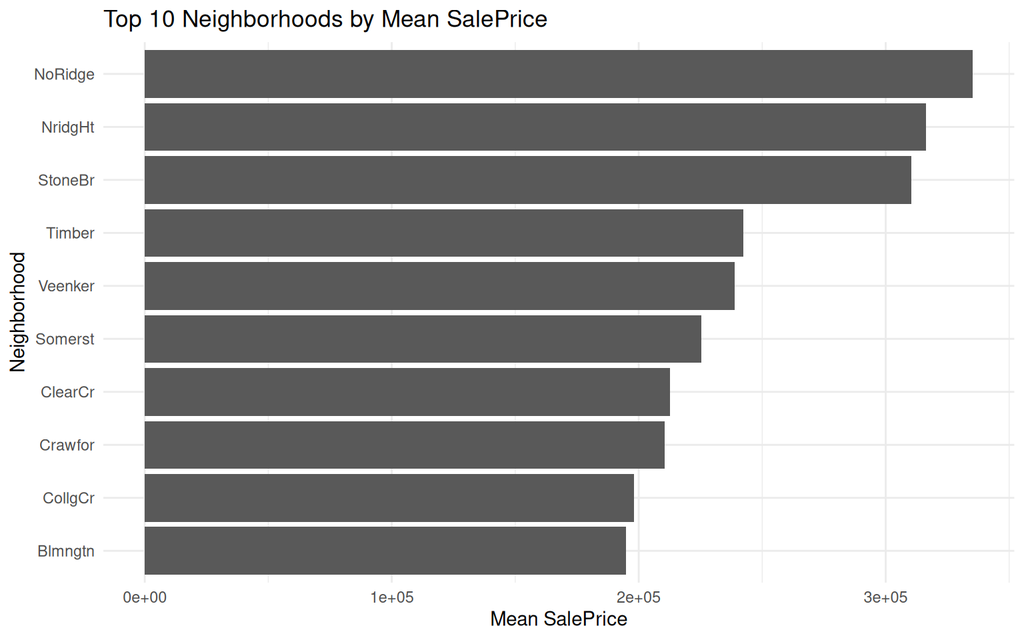

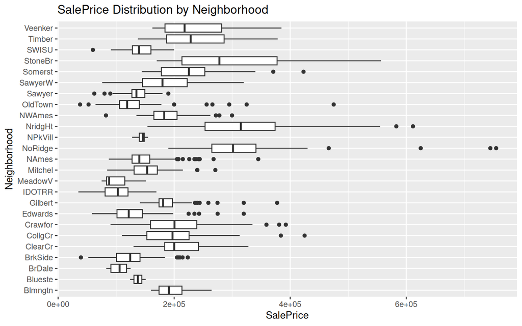

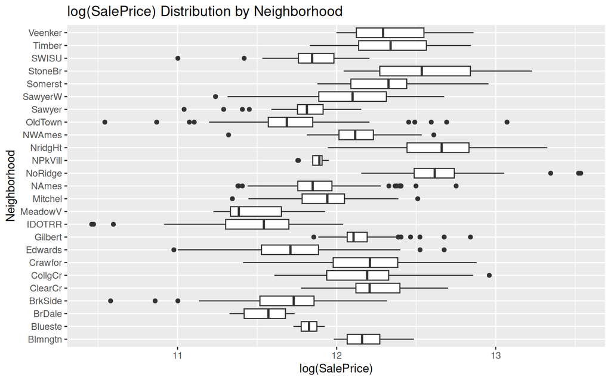

```
##
## Call:
## lm(formula = SalePrice_log ~ Neighborhood + GrLivArea + TotalBsmtSF +
##     GarageArea + OverallQual + YearBuilt, data = train)
##
## Coefficients:
##         (Intercept)  NeighborhoodBlueste   NeighborhoodBrDale
##           7.314e+00           -1.077e-01           -2.402e-01
## NeighborhoodBrkSide  NeighborhoodClearCr  NeighborhoodCollgCr
##          -9.973e-03            1.970e-01            4.921e-02
## NeighborhoodCrawfor  NeighborhoodEdwards  NeighborhoodGilbert
##           2.028e-01           -7.232e-02            6.099e-02
##  NeighborhoodIDOTRR  NeighborhoodMeadowV  NeighborhoodMitchel
##          -1.964e-01           -1.824e-01            1.132e-02
##   NeighborhoodNAmes  NeighborhoodNoRidge  NeighborhoodNPkVill
##           2.181e-02            1.484e-01           -5.180e-02
## NeighborhoodNridgHt   NeighborhoodNWAmes  NeighborhoodOldTown
##           1.563e-01            3.495e-02           -8.674e-02
##  NeighborhoodSawyer  NeighborhoodSawyerW  NeighborhoodSomerst
##           2.390e-02            2.125e-02            6.133e-02
## NeighborhoodStoneBr    NeighborhoodSWISU   NeighborhoodTimber
##           1.867e-01           -1.320e-02            1.156e-01
## NeighborhoodVeenker            GrLivArea          TotalBsmtSF
##           2.233e-01            2.248e-04            8.749e-05
##          GarageArea          OverallQual            YearBuilt
##           2.336e-04            9.424e-02            1.808e-03
```

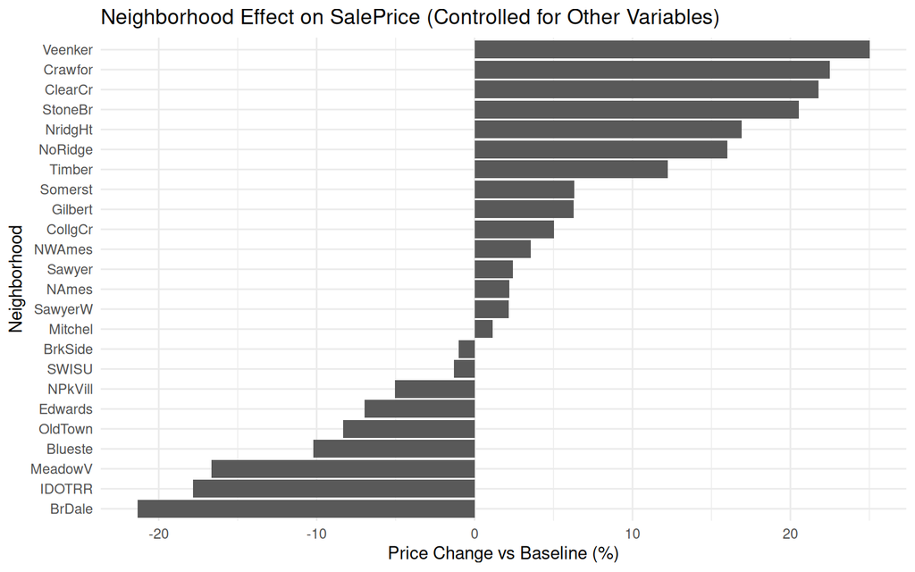

Descriptive Results (No Controls) We grouped properties by neighbourhood and summarised: • number of houses • mean price • median price Ranking by mean price: • Highest: NoRidge • Lowest: MeadowV This was further confirmed via boxplots and the Top 10 mean-price neighbourhood bar chart. These descriptive findings already demonstrate large spatial disparities.

Controlling for Structural Variables House prices are influenced by many factors beyond location. Using reference literature (Zoopla’s “10 Factors That Affect Home Value”), and selecting variables available in our dataset, we fitted the model:

Using log-transformed prices ensures normality and stabilises variance. Interpreting Neighbourhood Effects Regression coefficients for each neighbourhood were transformed into percentage effects relative to the baseline category.

Key Finding: Even after controlling for structural and quality characteristics, certain neighbourhoods retain strong price premiums. This confirms that location-based amenities, attractiveness, and socioeconomic factors play roles beyond home characteristics alone.

#2: Are Newer Houses Worth More?

```
## # A tibble: 3 × 4
##   YearGroup n_house mean_price median_price
##   <chr>       <int>      <dbl>        <dbl>
## 1 New           388    242439.       223750
## 2 Mid           224    217968.       194000
## 3 Old           848    142988.       136250
```

```
## # A tibble: 3 × 2
##   YearGroup n_house
##   <chr>       <int>
## 1 Mid           224
## 2 New           388
## 3 Old           848
```

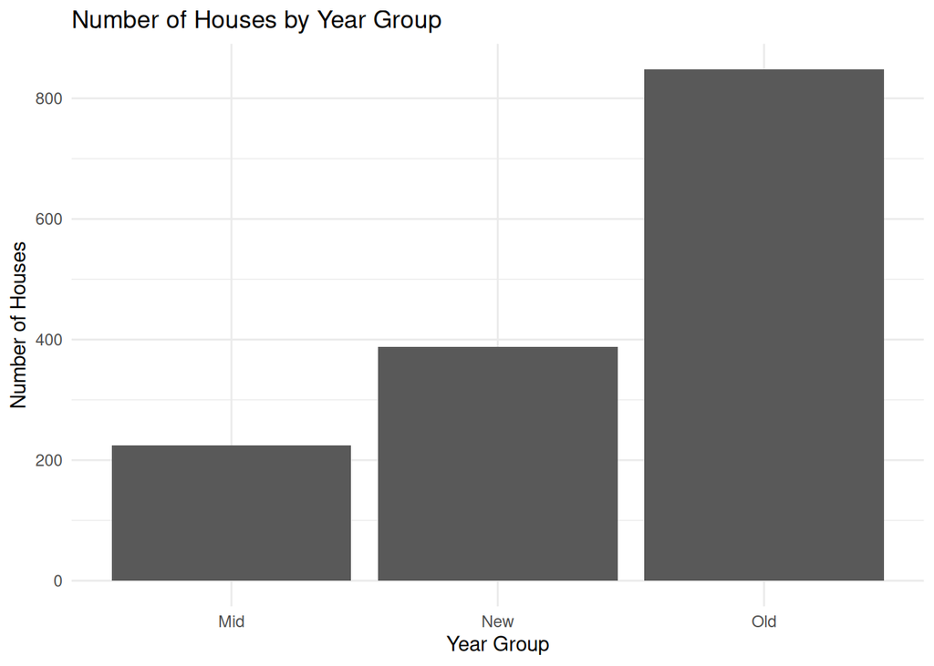

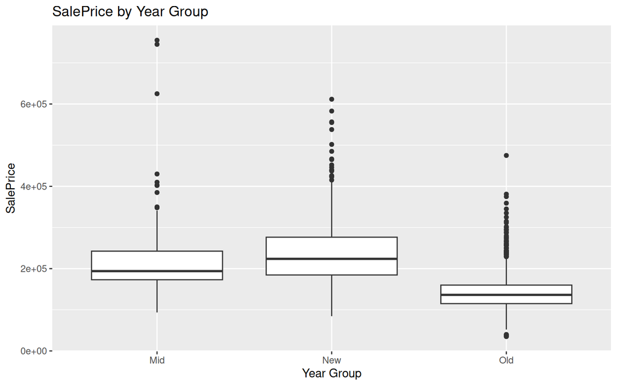

[output not shown]

```
##
## Call:
## lm(formula = SalePrice_log ~ YearGroup + GrLivArea + OverallQual +
##     TotalBsmtSF + GarageArea, data = train)
##
## Residuals:
##      Min       1Q   Median       3Q      Max
## -2.38901 -0.07767  0.00885  0.09906  0.62168
##
## Coefficients:
##                Estimate Std. Error t value Pr(>|t|)
## (Intercept)   1.078e+01  3.353e-02 321.541  < 2e-16 ***
## YearGroupNew -3.743e-03  1.580e-02  -0.237    0.813
## YearGroupOld -1.069e-01  1.516e-02  -7.054 2.67e-12 ***
## GrLivArea     2.147e-04  1.192e-05  18.014  < 2e-16 ***
## OverallQual   1.136e-01  5.822e-03  19.508  < 2e-16 ***
## TotalBsmtSF   1.307e-04  1.347e-05   9.705  < 2e-16 ***
## GarageArea    3.165e-04  2.869e-05  11.030  < 2e-16 ***
## ---
## Signif. codes:  0 '***' 0.001 '**' 0.01 '*' 0.05 '.' 0.1 ' ' 1
##
## Residual standard error: 0.1812 on 1453 degrees of freedom
## Multiple R-squared:  0.7951, Adjusted R-squared:  0.7943
## F-statistic: 939.9 on 6 and 1453 DF,  p-value: < 2.2e-16
```

```
## # A tibble: 2 × 2
##   term         estimate
##   <chr>           <dbl>
## 1 YearGroupNew   -0.374
## 2 YearGroupOld  -10.1
```

Grouping Houses by Age We grouped houses into three construction periods: • Old: built before 1980 • Mid: 1980–1999 • New: 2000 onward Summary statistics show: • Mean Price: New > Mid > Old • Median Price: same order Thus, newer houses tend to be more expensive.

Controlling for Key Structural Variables

#3: Building a Price-Class Classification Model

```
##
##  low high
##  732  728
```

```
## # A tibble: 4 × 3
##   HighPrice Street     n
##   <fct>     <chr>  <int>
## 1 low       Grvl       4
## 2 low       Pave     728
## 3 high      Grvl       2
## 4 high      Pave     726
```

```
## # A tibble: 6 × 3
##   HighPrice Alley       n
##   <fct>     <chr>   <int>
## 1 low       Grvl       45
## 2 low       NoAlley   670
## 3 low       Pave       17
## 4 high      Grvl        5
## 5 high      NoAlley   699
## 6 high      Pave       24
```

```
## # A tibble: 8 × 3
##   HighPrice LandContour     n
##   <fct>     <chr>       <int>
## 1 low       Bnk            45
## 2 low       HLS            14
## 3 low       Low            13
## 4 low       Lvl           660
## 5 high      Bnk            18
## 6 high      HLS            36
## 7 high      Low            23
## 8 high      Lvl           651
```

```
## # A tibble: 3 × 3
##   HighPrice Utilities     n
##   <fct>     <chr>     <int>
## 1 low       AllPub      731
## 2 low       NoSeWa        1
## 3 high      AllPub      728
```

```
## # A tibble: 6 × 3
##   HighPrice LandSlope     n
##   <fct>     <chr>     <int>
## 1 low       Gtl         702
## 2 low       Mod          25
## 3 low       Sev           5
## 4 high      Gtl         680
## 5 high      Mod          40
## 6 high      Sev           8
```

```
## # A tibble: 10 × 3
##    HighPrice Condition2     n
##    <fct>     <chr>      <int>
##  1 low       Artery         2
##  2 low       Feedr          5
##  3 low       Norm         722
##  4 low       RRAn           1
##  5 low       RRNn           2
##  6 high      Feedr          1
##  7 high      Norm         723
##  8 high      PosA           1
##  9 high      PosN           2
## 10 high      RRAe           1
```

```
## # A tibble: 10 × 3
##    HighPrice RoofMatl     n
##    <fct>     <chr>    <int>
##  1 low       ClyTile      1
##  2 low       CompShg    726
##  3 low       Roll         1
##  4 low       Tar&Grv      4
##  5 high      CompShg    708
##  6 high      Membran      1
##  7 high      Metal        1
##  8 high      Tar&Grv      7
##  9 high      WdShake      5
## 10 high      WdShngl      6
```

```
## # A tibble: 9 × 3
##   HighPrice BsmtCond     n
##   <fct>     <chr>    <int>
## 1 low       Fa          38
## 2 low       Gd          19
## 3 low       NoBsmt      35
## 4 low       Po           2
## 5 low       TA         638
## 6 high      Fa           7
## 7 high      Gd          46
## 8 high      NoBsmt       2
## 9 high      TA         673
```

```
## # A tibble: 14 × 3
##    HighPrice BsmtFinType2     n
##    <fct>     <chr>        <int>
##  1 low       ALQ              8
##  2 low       BLQ             23
##  3 low       GLQ              6
##  4 low       LwQ             26
##  5 low       NoBsmt          35
##  6 low       Rec             34
##  7 low       Unf            600
##  8 high      ALQ             11
##  9 high      BLQ             10
## 10 high      GLQ              8
## 11 high      LwQ             20
## 12 high      NoBsmt           3
## 13 high      Rec             20
## 14 high      Unf            656
```

```
## # A tibble: 151 × 3
##    HighPrice BsmtFinSF2     n
##    <fct>          <dbl> <int>
##  1 low                0   635
##  2 low               28     1
##  3 low               35     1
##  4 low               41     2
##  5 low               81     1
##  6 low               93     1
##  7 low               96     2
##  8 low              105     1
##  9 low              108     1
## 10 low              117     1
## # ℹ 141 more rows
```

```
## # A tibble: 8 × 3
##   HighPrice Heating     n
##   <fct>     <chr>   <int>
## 1 low       Floor       1
## 2 low       GasA      706
## 3 low       GasW       12
## 4 low       Grav        7
## 5 low       OthW        2
## 6 low       Wall        4
## 7 high      GasA      722
## 8 high      GasW        6
```

```
## # A tibble: 25 × 3
##    HighPrice LowQualFinSF     n
##    <fct>            <dbl> <int>
##  1 low                  0   714
##  2 low                 80     3
##  3 low                120     1
##  4 low                144     1
##  5 low                156     1
##  6 low                205     1
##  7 low                232     1
##  8 low                234     1
##  9 low                360     2
## 10 low                371     1
## # ℹ 15 more rows
```

```
## # A tibble: 6 × 3
##   HighPrice KitchenAbvGr     n
##   <fct>            <dbl> <int>
## 1 low                  0     1
## 2 low                  1   671
## 3 low                  2    58
## 4 low                  3     2
## 5 high                 1   721
## 6 high                 2     7
```

```
## # A tibble: 22 × 3
##    HighPrice `3SsnPorch`     n
##    <fct>           <dbl> <int>
##  1 low                 0   726
##  2 low               140     1
##  3 low               162     1
##  4 low               180     2
##  5 low               216     1
##  6 low               320     1
##  7 high                0   710
##  8 high               23     1
##  9 high               96     1
## 10 high              130     1
## # ℹ 12 more rows
```

```
## # A tibble: 86 × 3
##    HighPrice ScreenPorch     n
##    <fct>           <dbl> <int>
##  1 low                 0   691
##  2 low                40     1
##  3 low                60     1
##  4 low                63     1
##  5 low                80     1
##  6 low                90     1
##  7 low                95     1
##  8 low                99     1
##  9 low               100     1
## 10 low               120     3
## # ℹ 76 more rows
```

```
## # A tibble: 8 × 3
##   HighPrice MiscFeature     n
##   <fct>     <chr>       <int>
## 1 low       Gar2            1
## 2 low       None          696
## 3 low       Othr            2
## 4 low       Shed           33
## 5 high      Gar2            1
## 6 high      None          710
## 7 high      Shed           16
## 8 high      TenC            1
```

```
## # A tibble: 27 × 3
##    HighPrice MiscVal     n
##    <fct>       <dbl> <int>
##  1 low             0   698
##  2 low            54     1
##  3 low           400     7
##  4 low           450     4
##  5 low           480     1
##  6 low           500     4
##  7 low           560     1
##  8 low           600     4
##  9 low           620     1
## 10 low           700     3
## # ℹ 17 more rows
```

```
## # A tibble: 19 × 4
##    variable     type      role      source
##    <chr>        <list>    <chr>     <chr>
##  1 OverallQual  <chr [2]> predictor original
##  2 OverallCond  <chr [2]> predictor original
##  3 GrLivArea    <chr [2]> predictor original
##  4 TotalBsmtSF  <chr [2]> predictor original
##  5 BsmtFinSF1   <chr [2]> predictor original
##  6 BsmtExposure <chr [3]> predictor original
##  7 GarageArea   <chr [2]> predictor original
##  8 GarageQual   <chr [3]> predictor original
##  9 LotArea      <chr [2]> predictor original
## 10 KitchenQual  <chr [3]> predictor original
## 11 FullBath     <chr [2]> predictor original
## 12 HalfBath     <chr [2]> predictor original
## 13 ExterQual    <chr [3]> predictor original
## 14 ExterCond    <chr [3]> predictor original
## 15 YearBuilt    <chr [2]> predictor original
## 16 YearRemodAdd <chr [2]> predictor original
## 17 1stFlrSF     <chr [2]> predictor original
## 18 2ndFlrSF     <chr [2]> predictor original
## 19 HighPrice    <chr [3]> outcome   original
```

```
## # A tibble: 32 × 5
##    term           estimate    std.error statistic       p.value
##    <chr>             <dbl>        <dbl>     <dbl>         <dbl>
##  1 (Intercept) -94.2       1619.          -0.0582 0.954
##  2 OverallQual   0.957        0.165        5.79   0.00000000689
##  3 OverallCond   0.396        0.151        2.62   0.00880
##  4 GrLivArea     0.00171      0.00342      0.499  0.618
##  5 TotalBsmtSF   0.00126      0.000755     1.67   0.0947
##  6 BsmtFinSF1    0.000349     0.000351     0.992  0.321
##  7 GarageArea    0.000322     0.000892     0.362  0.718
##  8 LotArea       0.0000934    0.0000268    3.48   0.000502
##  9 FullBath      1.14         0.319        3.56   0.000367
## 10 HalfBath      1.11         0.297        3.75   0.000175
## # ℹ 22 more rows
```

```
## # A tibble: 6 × 3
##   .pred_low .pred_high HighPrice
##       <dbl>      <dbl> <fct>
## 1  0.000700   0.999    high
## 2  0.00353    0.996    high
## 3  0.00935    0.991    high
## 4  1.000      0.000196 low
## 5  0.820      0.180    low
## 6  1.000      0.000169 low
```

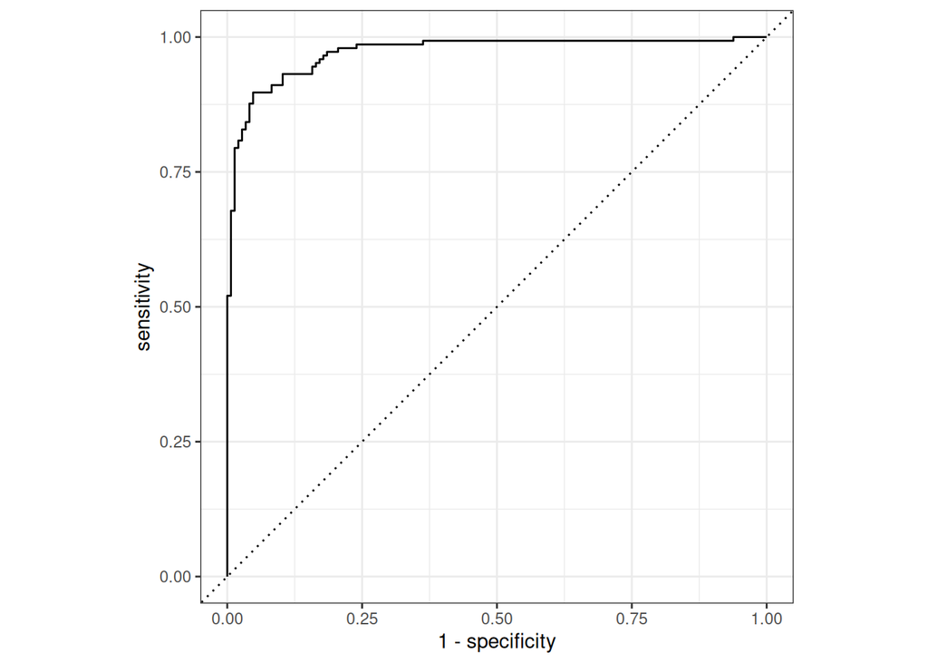

```
## # A tibble: 1 × 3
##   .metric .estimator .estimate
##   <chr>   <chr>          <dbl>
## 1 roc_auc binary         0.971
```

[figure not shown]

Defining High vs Low Price We defined: • high price: SalePrice > median • low price: SalePrice ≤ median This produced a balanced binary target variable. We used an 80/20 training-test split with stratification.

Variable Selection The initial attempt using all variables produced warnings:“fitted probabilities numerically 0 or 1 occurred” This implied perfect separation driven by variables with extremely dominant categories (e.g., factors where 99% of entries fall in one level). We manually removed these non-informative predictors and retained meaningful, balanced features such as: •OverallQual, OverallCond •GrLivArea • TotalBsmtSF, BsmtFinSF1, BsmtExposure • GarageArea,GarageQual • LotArea • KitchenQual, FullBath, HalfBath • ExterQual, ExterCond • YearBuilt, YearRemodAdd • 1stFlrSF, 2ndFlrSF These were converted to dummy variables via the recipe.

#4: How Strong and Stable Is the Effect of GrLivArea on Sale Price?— A Bootstrap Approach

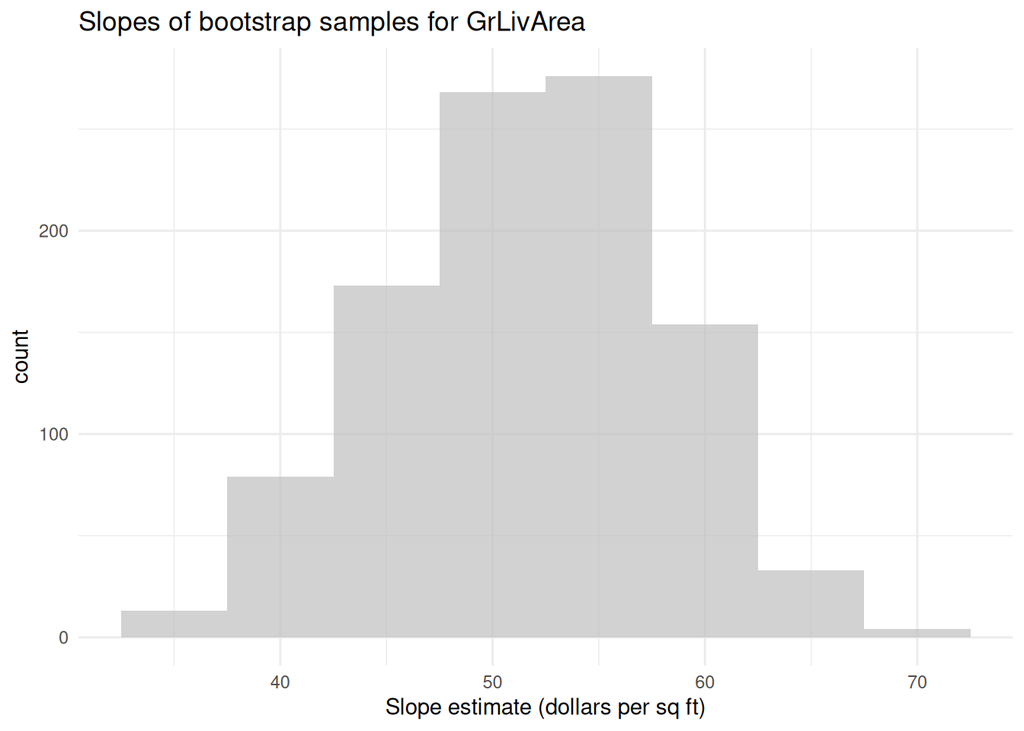

```
## # A tibble: 6 × 6
##   term            .lower .estimate    .upper .alpha .method
##   <chr>            <dbl>     <dbl>     <dbl>  <dbl> <chr>
## 1 (Intercept) -883407.   -732544.  -583397.    0.05 percentile
## 2 GarageArea       34.2       45.9      58.8   0.05 percentile
## 3 GrLivArea        39.0       51.7      63.3   0.05 percentile
## 4 OverallQual   16981.     20776.    25222.    0.05 percentile
## 5 TotalBsmtSF       8.25      28.7      45.7   0.05 percentile
## 6 YearBuilt       253.       333.      411.    0.05 percentile
```

```
## # A tibble: 1 × 6
##   term      .lower .estimate .upper .alpha .method
##   <chr>      <dbl>     <dbl>  <dbl>  <dbl> <chr>
## 1 GrLivArea   39.0      51.7   63.3   0.05 percentile
```

Distribution of GrLivArea Bootstrap Coefficients Interpretation •Coefficients cluster around 50–55 dollars per sq.ft • No negative or unstable estimates • Distribution is unimodal and tight. This demonstrates: GrLivArea is one of the most reliable predictors across all bootstrap samples.

Bootstrap 95% Confidence Interval Percentile interval: • Lower: $38.97/sq.ft • Upper: $63.28/sq.ft

Interpretation：Holding all other variables constant: Each additional square foot of above-ground living area increases sale price by $38.97–$63.28 (95% CI). Confidence interval is narrow and entirely positive → strong structural importance.

##Discussion & Insights # Neighbourhood Matters—Even After Adjusting for Structural Features Neighbourhood remains one of the strongest determinants of price. This suggests that buyers value local amenities, safety, schools, and community characteristics beyond physical house features.

# Age and Price—Not a Simple Linear Relationship

# Predictive Modelling Shows Strong Potential

## Conclusions

This project provides a comprehensive examination of how neighborhood, structural features, and construction era interact to shape housing prices in Ames, Iowa. Regression models show that both location and quality exert strong effects, while classification models accurately distinguish high-value homes.Bootstrap analysis further confirms the robustness of key predictors, highlighting the reliability of living area as a primary driver of market value.  
These findings demonstrate how statistical modeling and resampling techniques can be used to extract meaningful insights from real-estate data and support informed decision-making.

##Reference Kaggle. (n.d.). House Prices: Advanced Regression Techniques - Data. Kaggle. Retrieved from https://www.kaggle.com/competitions/house-prices-advanced-regression-techniques/data